# Risk Factor Analysis

## Outcome Variable

**Outcome Variable:** ever_co

## Predictor Variables

**Intervention Variable:** impsan

**Adjustment Set:**

- arm
- sex
- W_mage
- meducyrs
- feducyrs
- hhwealth_quart
- hfoodsec
- W_mhtcm
- W_mwtkg
- W_mbmi
- W_nrooms
- W_nchldlt5
- W_parity
- impfloor
- safeh20
- delta_W_mage
- delta_meducyrs
- delta_feducyrs
- delta_hhwealth_quart
- delta_hfoodsec
- delta_W_mhtcm
- delta_W_mwtkg
- delta_W_mbmi
- delta_W_nrooms
- delta_W_nchldlt5
- delta_W_parity
- delta_impfloor
- delta_safeh20

## Stratifying Variables

The analysis was stratified on these variable(s):

- agecat
- studyid
- country

## Data Summary

| agecat | studyid | country | impsan | ever_co | n_cell | n |
| --- | --- | --- | --- | --- | --- | --- |
| 0-24 months | COHORTS | GUATEMALA | 1 | 0 | 76 | 875 |
| 0-24 months | COHORTS | GUATEMALA | 1 | 1 | 6 | 875 |
| 0-24 months | COHORTS | GUATEMALA | 0 | 0 | 677 | 875 |
| 0-24 months | COHORTS | GUATEMALA | 0 | 1 | 116 | 875 |
| 0-24 months | COHORTS | INDIA | 1 | 0 | 1908 | 5372 |
| 0-24 months | COHORTS | INDIA | 1 | 1 | 106 | 5372 |
| 0-24 months | COHORTS | INDIA | 0 | 0 | 2937 | 5372 |
| 0-24 months | COHORTS | INDIA | 0 | 1 | 421 | 5372 |
| 0-24 months | COHORTS | PHILIPPINES | 1 | 0 | 168 | 1191 |
| 0-24 months | COHORTS | PHILIPPINES | 1 | 1 | 11 | 1191 |
| 0-24 months | COHORTS | PHILIPPINES | 0 | 0 | 778 | 1191 |
| 0-24 months | COHORTS | PHILIPPINES | 0 | 1 | 234 | 1191 |
| 0-24 months | CONTENT | PERU | 1 | 0 | 201 | 215 |
| 0-24 months | CONTENT | PERU | 1 | 1 | 0 | 215 |
| 0-24 months | CONTENT | PERU | 0 | 0 | 14 | 215 |
| 0-24 months | CONTENT | PERU | 0 | 1 | 0 | 215 |
| 0-24 months | JiVitA-3 | BANGLADESH | 1 | 0 | 17250 | 26894 |
| 0-24 months | JiVitA-3 | BANGLADESH | 1 | 1 | 1490 | 26894 |
| 0-24 months | JiVitA-3 | BANGLADESH | 0 | 0 | 7255 | 26894 |
| 0-24 months | JiVitA-3 | BANGLADESH | 0 | 1 | 899 | 26894 |
| 0-24 months | JiVitA-4 | BANGLADESH | 1 | 0 | 3557 | 5426 |
| 0-24 months | JiVitA-4 | BANGLADESH | 1 | 1 | 631 | 5426 |
| 0-24 months | JiVitA-4 | BANGLADESH | 0 | 0 | 993 | 5426 |
| 0-24 months | JiVitA-4 | BANGLADESH | 0 | 1 | 245 | 5426 |
| 0-24 months | LCNI-5 | MALAWI | 1 | 0 | 3 | 813 |
| 0-24 months | LCNI-5 | MALAWI | 1 | 1 | 0 | 813 |
| 0-24 months | LCNI-5 | MALAWI | 0 | 0 | 768 | 813 |
| 0-24 months | LCNI-5 | MALAWI | 0 | 1 | 42 | 813 |
| 0-24 months | MAL-ED | BANGLADESH | 1 | 0 | 171 | 242 |
| 0-24 months | MAL-ED | BANGLADESH | 1 | 1 | 33 | 242 |

[output cut: 174 more lines]

The following strata were considered:

- agecat: 0-24 months, studyid: COHORTS, country: GUATEMALA
- agecat: 0-24 months, studyid: COHORTS, country: INDIA
- agecat: 0-24 months, studyid: COHORTS, country: PHILIPPINES
- agecat: 0-24 months, studyid: CONTENT, country: PERU
- agecat: 0-24 months, studyid: JiVitA-3, country: BANGLADESH
- agecat: 0-24 months, studyid: JiVitA-4, country: BANGLADESH
- agecat: 0-24 months, studyid: LCNI-5, country: MALAWI
- agecat: 0-24 months, studyid: MAL-ED, country: BANGLADESH
- agecat: 0-24 months, studyid: MAL-ED, country: BRAZIL
- agecat: 0-24 months, studyid: MAL-ED, country: INDIA
- agecat: 0-24 months, studyid: MAL-ED, country: NEPAL
- agecat: 0-24 months, studyid: MAL-ED, country: PERU
- agecat: 0-24 months, studyid: MAL-ED, country: SOUTH AFRICA
- agecat: 0-24 months, studyid: MAL-ED, country: TANZANIA, UNITED REPUBLIC OF
- agecat: 0-24 months, studyid: NIH-Birth, country: BANGLADESH
- agecat: 0-24 months, studyid: NIH-Crypto, country: BANGLADESH
- agecat: 0-24 months, studyid: PROVIDE, country: BANGLADESH
- agecat: 0-6 months, studyid: COHORTS, country: GUATEMALA
- agecat: 0-6 months, studyid: COHORTS, country: INDIA
- agecat: 0-6 months, studyid: COHORTS, country: PHILIPPINES
- agecat: 0-6 months, studyid: CONTENT, country: PERU
- agecat: 0-6 months, studyid: JiVitA-3, country: BANGLADESH
- agecat: 0-6 months, studyid: JiVitA-4, country: BANGLADESH
- agecat: 0-6 months, studyid: LCNI-5, country: MALAWI
- agecat: 0-6 months, studyid: MAL-ED, country: BANGLADESH
- agecat: 0-6 months, studyid: MAL-ED, country: BRAZIL
- agecat: 0-6 months, studyid: MAL-ED, country: INDIA
- agecat: 0-6 months, studyid: MAL-ED, country: NEPAL
- agecat: 0-6 months, studyid: MAL-ED, country: PERU
- agecat: 0-6 months, studyid: MAL-ED, country: SOUTH AFRICA
- agecat: 0-6 months, studyid: MAL-ED, country: TANZANIA, UNITED REPUBLIC OF
- agecat: 0-6 months, studyid: NIH-Birth, country: BANGLADESH
- agecat: 0-6 months, studyid: NIH-Crypto, country: BANGLADESH
- agecat: 0-6 months, studyid: PROVIDE, country: BANGLADESH
- agecat: 6-24 months, studyid: COHORTS, country: GUATEMALA
- agecat: 6-24 months, studyid: COHORTS, country: INDIA
- agecat: 6-24 months, studyid: COHORTS, country: PHILIPPINES
- agecat: 6-24 months, studyid: CONTENT, country: PERU
- agecat: 6-24 months, studyid: JiVitA-3, country: BANGLADESH
- agecat: 6-24 months, studyid: JiVitA-4, country: BANGLADESH
- agecat: 6-24 months, studyid: LCNI-5, country: MALAWI
- agecat: 6-24 months, studyid: MAL-ED, country: BANGLADESH
- agecat: 6-24 months, studyid: MAL-ED, country: BRAZIL
- agecat: 6-24 months, studyid: MAL-ED, country: INDIA
- agecat: 6-24 months, studyid: MAL-ED, country: NEPAL
- agecat: 6-24 months, studyid: MAL-ED, country: PERU
- agecat: 6-24 months, studyid: MAL-ED, country: SOUTH AFRICA
- agecat: 6-24 months, studyid: MAL-ED, country: TANZANIA, UNITED REPUBLIC OF
- agecat: 6-24 months, studyid: NIH-Birth, country: BANGLADESH
- agecat: 6-24 months, studyid: NIH-Crypto, country: BANGLADESH
- agecat: 6-24 months, studyid: PROVIDE, country: BANGLADESH

### Dropped Strata

Some strata were dropped due to rare outcomes:

- agecat: 0-24 months, studyid: CONTENT, country: PERU
- agecat: 0-24 months, studyid: LCNI-5, country: MALAWI
- agecat: 0-24 months, studyid: MAL-ED, country: BRAZIL
- agecat: 0-24 months, studyid: MAL-ED, country: NEPAL
- agecat: 0-24 months, studyid: MAL-ED, country: SOUTH AFRICA
- agecat: 0-24 months, studyid: MAL-ED, country: TANZANIA, UNITED REPUBLIC OF
- agecat: 0-24 months, studyid: PROVIDE, country: BANGLADESH
- agecat: 0-6 months, studyid: COHORTS, country: GUATEMALA
- agecat: 0-6 months, studyid: COHORTS, country: PHILIPPINES
- agecat: 0-6 months, studyid: CONTENT, country: PERU
- agecat: 0-6 months, studyid: LCNI-5, country: MALAWI
- agecat: 0-6 months, studyid: MAL-ED, country: BANGLADESH
- agecat: 0-6 months, studyid: MAL-ED, country: BRAZIL
- agecat: 0-6 months, studyid: MAL-ED, country: NEPAL
- agecat: 0-6 months, studyid: MAL-ED, country: PERU
- agecat: 0-6 months, studyid: MAL-ED, country: SOUTH AFRICA
- agecat: 0-6 months, studyid: MAL-ED, country: TANZANIA, UNITED REPUBLIC OF
- agecat: 0-6 months, studyid: NIH-Crypto, country: BANGLADESH
- agecat: 0-6 months, studyid: PROVIDE, country: BANGLADESH
- agecat: 6-24 months, studyid: CONTENT, country: PERU
- agecat: 6-24 months, studyid: LCNI-5, country: MALAWI
- agecat: 6-24 months, studyid: MAL-ED, country: BRAZIL
- agecat: 6-24 months, studyid: MAL-ED, country: NEPAL
- agecat: 6-24 months, studyid: MAL-ED, country: SOUTH AFRICA
- agecat: 6-24 months, studyid: MAL-ED, country: TANZANIA, UNITED REPUBLIC OF
- agecat: 6-24 months, studyid: PROVIDE, country: BANGLADESH

## Methods Detail

We’re interested in the causal parameters $E[Y_a]$ for all values of $a \in \mathcal{A}$. These parameters represent the mean outcome if, possibly contrary to fact, we intervened to set all units to have $A=a$. Under the randomization and positivity assumptions, these are identified by the statistical parameters $\psi_a=E_W[E_{Y|A,W}(Y|A=a,W)]$. In addition, we’re interested in the mean of $Y$, $E[Y]$ under no intervention (the observed mean). We will estimate these parameters by using SuperLearner to fit the relevant likelihood factors – $E_{Y|A,W}(Y|A=a,W)$ and $p(A=a|W)$, and then updating our likelihood fit using a joint TMLE.

For unadjusted analyses ($W=\{\}$), initial likelihoods were estimated using Lrnr_glm to estimate the simple $E(Y|A)$ and Lrnr_mean to estimate $p(A)$. For adjusted analyses, a small library containing Lrnr_glmnet, Lrnr_xgboost, and Lrnr_mean was used.

Having estimated these parameters, we will then use the delta method to estimate relative risks and attributable risks relative to a prespecified baseline level of $A$.

# Results Detail

## Results Plots

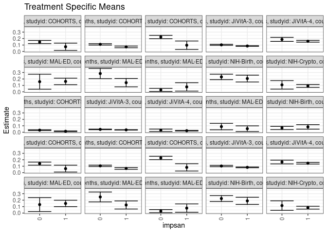

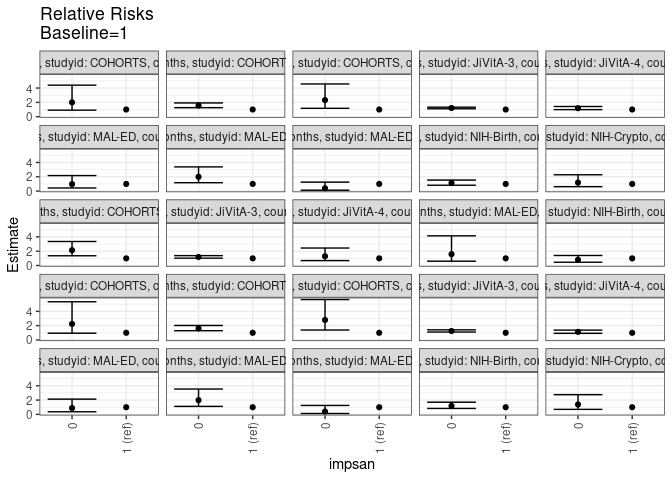

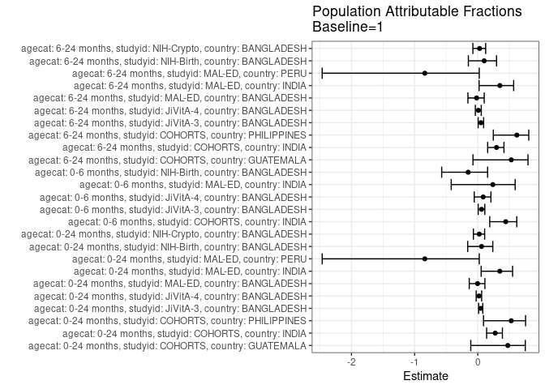

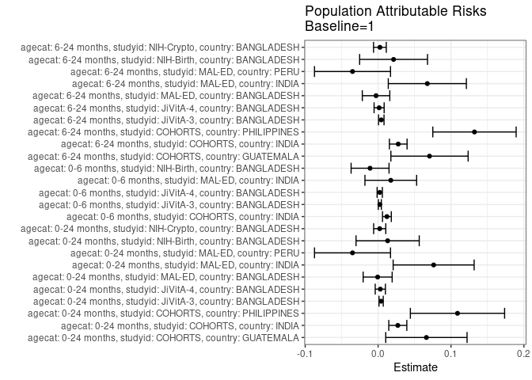

## Results Table

### Parameter: TSM

| agecat | studyid | country | intervention_level | baseline_level | estimate | ci_lower | ci_upper |
| --- | --- | --- | --- | --- | --- | --- | --- |
| 0-24 months | COHORTS | GUATEMALA | 1 | NA | 0.0731707 | 0.0167735 | 0.1295680 |
| 0-24 months | COHORTS | GUATEMALA | 0 | NA | 0.1462799 | 0.1216700 | 0.1708899 |
| 0-24 months | COHORTS | INDIA | 1 | NA | 0.0710709 | 0.0575352 | 0.0846067 |
| 0-24 months | COHORTS | INDIA | 0 | NA | 0.1103209 | 0.0999458 | 0.1206959 |
| 0-24 months | COHORTS | PHILIPPINES | 1 | NA | 0.0968116 | 0.0318406 | 0.1617826 |
| 0-24 months | COHORTS | PHILIPPINES | 0 | NA | 0.2239383 | 0.1980394 | 0.2498371 |
| 0-24 months | JiVitA-3 | BANGLADESH | 1 | NA | 0.0846841 | 0.0797491 | 0.0896190 |
| 0-24 months | JiVitA-3 | BANGLADESH | 0 | NA | 0.1024826 | 0.0941692 | 0.1107961 |
| 0-24 months | JiVitA-4 | BANGLADESH | 1 | NA | 0.1584032 | 0.1450551 | 0.1717513 |
| 0-24 months | JiVitA-4 | BANGLADESH | 0 | NA | 0.1871075 | 0.1560112 | 0.2182038 |
| 0-24 months | MAL-ED | BANGLADESH | 1 | NA | 0.1617647 | 0.1111290 | 0.2124004 |
| 0-24 months | MAL-ED | BANGLADESH | 0 | NA | 0.1578947 | 0.0417171 | 0.2740724 |
| 0-24 months | MAL-ED | INDIA | 1 | NA | 0.1426894 | 0.0778997 | 0.2074790 |
| 0-24 months | MAL-ED | INDIA | 0 | NA | 0.2842517 | 0.2048665 | 0.3636369 |
| 0-24 months | MAL-ED | PERU | 1 | NA | 0.0769231 | 0.0120199 | 0.1418262 |
| 0-24 months | MAL-ED | PERU | 0 | NA | 0.0303030 | 0.0063807 | 0.0542254 |
| 0-24 months | NIH-Birth | BANGLADESH | 1 | NA | 0.2064703 | 0.1533703 | 0.2595702 |
| 0-24 months | NIH-Birth | BANGLADESH | 0 | NA | 0.2318063 | 0.1889537 | 0.2746589 |
| 0-24 months | NIH-Crypto | BANGLADESH | 1 | NA | 0.0914994 | 0.0693884 | 0.1136104 |
| 0-24 months | NIH-Crypto | BANGLADESH | 0 | NA | 0.1085827 | 0.0426235 | 0.1745419 |
| 0-6 months | COHORTS | INDIA | 1 | NA | 0.0152018 | 0.0089681 | 0.0214354 |
| 0-6 months | COHORTS | INDIA | 0 | NA | 0.0325391 | 0.0265209 | 0.0385572 |
| 0-6 months | JiVitA-3 | BANGLADESH | 1 | NA | 0.0372549 | 0.0339221 | 0.0405877 |
| 0-6 months | JiVitA-3 | BANGLADESH | 0 | NA | 0.0444390 | 0.0392659 | 0.0496121 |
| 0-6 months | JiVitA-4 | BANGLADESH | 1 | NA | 0.0241280 | 0.0187381 | 0.0295179 |
| 0-6 months | JiVitA-4 | BANGLADESH | 0 | NA | 0.0312794 | 0.0122658 | 0.0502930 |
| 0-6 months | MAL-ED | INDIA | 1 | NA | 0.0555556 | 0.0122621 | 0.0988490 |
| 0-6 months | MAL-ED | INDIA | 0 | NA | 0.0880000 | 0.0382302 | 0.1377698 |
| 0-6 months | NIH-Birth | BANGLADESH | 1 | NA | 0.0833485 | 0.0487470 | 0.1179500 |
| 0-6 months | NIH-Birth | BANGLADESH | 0 | NA | 0.0668652 | 0.0418785 | 0.0918519 |
| 6-24 months | COHORTS | GUATEMALA | 1 | NA | 0.0625000 | 0.0094259 | 0.1155741 |
| 6-24 months | COHORTS | GUATEMALA | 0 | NA | 0.1402831 | 0.1158504 | 0.1647158 |
| 6-24 months | COHORTS | INDIA | 1 | NA | 0.0653532 | 0.0521143 | 0.0785921 |
| 6-24 months | COHORTS | INDIA | 0 | NA | 0.1056151 | 0.0949990 | 0.1162312 |
| 6-24 months | COHORTS | PHILIPPINES | 1 | NA | 0.0816353 | 0.0250510 | 0.1382195 |
| 6-24 months | COHORTS | PHILIPPINES | 0 | NA | 0.2281497 | 0.2017786 | 0.2545208 |
| 6-24 months | JiVitA-3 | BANGLADESH | 1 | NA | 0.0824438 | 0.0765568 | 0.0883307 |
| 6-24 months | JiVitA-3 | BANGLADESH | 0 | NA | 0.1029274 | 0.0922687 | 0.1135862 |
| 6-24 months | JiVitA-4 | BANGLADESH | 1 | NA | 0.1463317 | 0.1333985 | 0.1592649 |
| 6-24 months | JiVitA-4 | BANGLADESH | 0 | NA | 0.1652541 | 0.1361424 | 0.1943659 |
| 6-24 months | MAL-ED | BANGLADESH | 1 | NA | 0.1492537 | 0.0998883 | 0.1986192 |
| 6-24 months | MAL-ED | BANGLADESH | 0 | NA | 0.1315789 | 0.0238766 | 0.2392813 |
| 6-24 months | MAL-ED | INDIA | 1 | NA | 0.1256083 | 0.0631453 | 0.1880713 |
| 6-24 months | MAL-ED | INDIA | 0 | NA | 0.2497869 | 0.1730352 | 0.3265386 |
| 6-24 months | MAL-ED | PERU | 1 | NA | 0.0769231 | 0.0120199 | 0.1418262 |
| 6-24 months | MAL-ED | PERU | 0 | NA | 0.0303030 | 0.0063807 | 0.0542254 |
| 6-24 months | NIH-Birth | BANGLADESH | 1 | NA | 0.1890997 | 0.1334027 | 0.2447966 |
| 6-24 months | NIH-Birth | BANGLADESH | 0 | NA | 0.2251314 | 0.1791289 | 0.2711339 |
| 6-24 months | NIH-Crypto | BANGLADESH | 1 | NA | 0.0837494 | 0.0619880 | 0.1055108 |
| 6-24 months | NIH-Crypto | BANGLADESH | 0 | NA | 0.1162418 | 0.0424098 | 0.1900737 |

### Parameter: E(Y)

| agecat | studyid | country | intervention_level | baseline_level | estimate | ci_lower | ci_upper |
| --- | --- | --- | --- | --- | --- | --- | --- |
| 0-24 months | COHORTS | GUATEMALA | NA | NA | 0.1394286 | 0.1164638 | 0.1623933 |
| 0-24 months | COHORTS | INDIA | NA | NA | 0.0981013 | 0.0901463 | 0.1060562 |
| 0-24 months | COHORTS | PHILIPPINES | NA | NA | 0.2057095 | 0.1827432 | 0.2286758 |
| 0-24 months | JiVitA-3 | BANGLADESH | NA | NA | 0.0888302 | 0.0849233 | 0.0927371 |
| 0-24 months | JiVitA-4 | BANGLADESH | NA | NA | 0.1614449 | 0.1501252 | 0.1727646 |
| 0-24 months | MAL-ED | BANGLADESH | NA | NA | 0.1611570 | 0.1147371 | 0.2075770 |
| 0-24 months | MAL-ED | INDIA | NA | NA | 0.2188841 | 0.1656771 | 0.2720911 |
| 0-24 months | MAL-ED | PERU | NA | NA | 0.0418251 | 0.0175848 | 0.0660654 |
| 0-24 months | NIH-Birth | BANGLADESH | NA | NA | 0.2195513 | 0.1870467 | 0.2520558 |
| 0-24 months | NIH-Crypto | BANGLADESH | NA | NA | 0.0937082 | 0.0727959 | 0.1146204 |
| 0-6 months | COHORTS | INDIA | NA | NA | 0.0272886 | 0.0228458 | 0.0317313 |
| 0-6 months | JiVitA-3 | BANGLADESH | NA | NA | 0.0396461 | 0.0371429 | 0.0421492 |
| 0-6 months | JiVitA-4 | BANGLADESH | NA | NA | 0.0263831 | 0.0210411 | 0.0317252 |
| 0-6 months | MAL-ED | INDIA | NA | NA | 0.0729614 | 0.0394957 | 0.1064270 |
| 0-6 months | NIH-Birth | BANGLADESH | NA | NA | 0.0723473 | 0.0519719 | 0.0927227 |
| 6-24 months | COHORTS | GUATEMALA | NA | NA | 0.1330222 | 0.1102724 | 0.1557720 |
| 6-24 months | COHORTS | INDIA | NA | NA | 0.0929723 | 0.0849408 | 0.1010038 |
| 6-24 months | COHORTS | PHILIPPINES | NA | NA | 0.2138365 | 0.1897378 | 0.2379351 |
| 6-24 months | JiVitA-3 | BANGLADESH | NA | NA | 0.0868080 | 0.0821493 | 0.0914667 |
| 6-24 months | JiVitA-4 | BANGLADESH | NA | NA | 0.1477315 | 0.1371478 | 0.1583151 |
| 6-24 months | MAL-ED | BANGLADESH | NA | NA | 0.1464435 | 0.1015265 | 0.1913605 |
| 6-24 months | MAL-ED | INDIA | NA | NA | 0.1931330 | 0.1423366 | 0.2439295 |
| 6-24 months | MAL-ED | PERU | NA | NA | 0.0418251 | 0.0175848 | 0.0660654 |
| 6-24 months | NIH-Birth | BANGLADESH | NA | NA | 0.2103321 | 0.1759902 | 0.2446740 |
| 6-24 months | NIH-Crypto | BANGLADESH | NA | NA | 0.0862309 | 0.0656987 | 0.1067631 |

### Parameter: RR

| agecat | studyid | country | intervention_level | baseline_level | estimate | ci_lower | ci_upper |
| --- | --- | --- | --- | --- | --- | --- | --- |
| 0-24 months | COHORTS | GUATEMALA | 1 | 1 | 1.0000000 | 1.0000000 | 1.000000 |
| 0-24 months | COHORTS | GUATEMALA | 0 | 1 | 1.9991593 | 0.9082974 | 4.400142 |
| 0-24 months | COHORTS | INDIA | 1 | 1 | 1.0000000 | 1.0000000 | 1.000000 |
| 0-24 months | COHORTS | INDIA | 0 | 1 | 1.5522647 | 1.2566993 | 1.917345 |
| 0-24 months | COHORTS | PHILIPPINES | 1 | 1 | 1.0000000 | 1.0000000 | 1.000000 |
| 0-24 months | COHORTS | PHILIPPINES | 0 | 1 | 2.3131337 | 1.1709419 | 4.569473 |
| 0-24 months | JiVitA-3 | BANGLADESH | 1 | 1 | 1.0000000 | 1.0000000 | 1.000000 |
| 0-24 months | JiVitA-3 | BANGLADESH | 0 | 1 | 1.2101762 | 1.1014419 | 1.329645 |
| 0-24 months | JiVitA-4 | BANGLADESH | 1 | 1 | 1.0000000 | 1.0000000 | 1.000000 |
| 0-24 months | JiVitA-4 | BANGLADESH | 0 | 1 | 1.1812103 | 0.9842298 | 1.417614 |
| 0-24 months | MAL-ED | BANGLADESH | 1 | 1 | 1.0000000 | 1.0000000 | 1.000000 |
| 0-24 months | MAL-ED | BANGLADESH | 0 | 1 | 0.9760766 | 0.4387519 | 2.171445 |
| 0-24 months | MAL-ED | INDIA | 1 | 1 | 1.0000000 | 1.0000000 | 1.000000 |
| 0-24 months | MAL-ED | INDIA | 0 | 1 | 1.9921015 | 1.1729353 | 3.383365 |
| 0-24 months | MAL-ED | PERU | 1 | 1 | 1.0000000 | 1.0000000 | 1.000000 |
| 0-24 months | MAL-ED | PERU | 0 | 1 | 0.3939394 | 0.1240553 | 1.250961 |
| 0-24 months | NIH-Birth | BANGLADESH | 1 | 1 | 1.0000000 | 1.0000000 | 1.000000 |
| 0-24 months | NIH-Birth | BANGLADESH | 0 | 1 | 1.1227104 | 0.8186043 | 1.539790 |
| 0-24 months | NIH-Crypto | BANGLADESH | 1 | 1 | 1.0000000 | 1.0000000 | 1.000000 |
| 0-24 months | NIH-Crypto | BANGLADESH | 0 | 1 | 1.1867045 | 0.6170127 | 2.282396 |
| 0-6 months | COHORTS | INDIA | 1 | 1 | 1.0000000 | 1.0000000 | 1.000000 |
| 0-6 months | COHORTS | INDIA | 0 | 1 | 2.1404817 | 1.3651864 | 3.356071 |
| 0-6 months | JiVitA-3 | BANGLADESH | 1 | 1 | 1.0000000 | 1.0000000 | 1.000000 |
| 0-6 months | JiVitA-3 | BANGLADESH | 0 | 1 | 1.1928370 | 1.0279224 | 1.384210 |
| 0-6 months | JiVitA-4 | BANGLADESH | 1 | 1 | 1.0000000 | 1.0000000 | 1.000000 |
| 0-6 months | JiVitA-4 | BANGLADESH | 0 | 1 | 1.2963948 | 0.6883031 | 2.441714 |
| 0-6 months | MAL-ED | INDIA | 1 | 1 | 1.0000000 | 1.0000000 | 1.000000 |
| 0-6 months | MAL-ED | INDIA | 0 | 1 | 1.5840000 | 0.6047559 | 4.148874 |
| 0-6 months | NIH-Birth | BANGLADESH | 1 | 1 | 1.0000000 | 1.0000000 | 1.000000 |
| 0-6 months | NIH-Birth | BANGLADESH | 0 | 1 | 0.8022366 | 0.4593868 | 1.400962 |
| 6-24 months | COHORTS | GUATEMALA | 1 | 1 | 1.0000000 | 1.0000000 | 1.000000 |
| 6-24 months | COHORTS | GUATEMALA | 0 | 1 | 2.2445302 | 0.9433052 | 5.340706 |
| 6-24 months | COHORTS | INDIA | 1 | 1 | 1.0000000 | 1.0000000 | 1.000000 |
| 6-24 months | COHORTS | INDIA | 0 | 1 | 1.6160660 | 1.2907846 | 2.023319 |
| 6-24 months | COHORTS | PHILIPPINES | 1 | 1 | 1.0000000 | 1.0000000 | 1.000000 |
| 6-24 months | COHORTS | PHILIPPINES | 0 | 1 | 2.7947443 | 1.3838338 | 5.644172 |
| 6-24 months | JiVitA-3 | BANGLADESH | 1 | 1 | 1.0000000 | 1.0000000 | 1.000000 |
| 6-24 months | JiVitA-3 | BANGLADESH | 0 | 1 | 1.2484563 | 1.1043864 | 1.411320 |
| 6-24 months | JiVitA-4 | BANGLADESH | 1 | 1 | 1.0000000 | 1.0000000 | 1.000000 |
| 6-24 months | JiVitA-4 | BANGLADESH | 0 | 1 | 1.1293122 | 0.9260288 | 1.377221 |
| 6-24 months | MAL-ED | BANGLADESH | 1 | 1 | 1.0000000 | 1.0000000 | 1.000000 |
| 6-24 months | MAL-ED | BANGLADESH | 0 | 1 | 0.8815789 | 0.3646285 | 2.131434 |
| 6-24 months | MAL-ED | INDIA | 1 | 1 | 1.0000000 | 1.0000000 | 1.000000 |
| 6-24 months | MAL-ED | INDIA | 0 | 1 | 1.9886180 | 1.1161816 | 3.542973 |
| 6-24 months | MAL-ED | PERU | 1 | 1 | 1.0000000 | 1.0000000 | 1.000000 |
| 6-24 months | MAL-ED | PERU | 0 | 1 | 0.3939394 | 0.1240553 | 1.250961 |
| 6-24 months | NIH-Birth | BANGLADESH | 1 | 1 | 1.0000000 | 1.0000000 | 1.000000 |
| 6-24 months | NIH-Birth | BANGLADESH | 0 | 1 | 1.1905438 | 0.8328311 | 1.701899 |
| 6-24 months | NIH-Crypto | BANGLADESH | 1 | 1 | 1.0000000 | 1.0000000 | 1.000000 |
| 6-24 months | NIH-Crypto | BANGLADESH | 0 | 1 | 1.3879715 | 0.6986740 | 2.757316 |

### Parameter: PAR

| agecat | studyid | country | intervention_level | baseline_level | estimate | ci_lower | ci_upper |
| --- | --- | --- | --- | --- | --- | --- | --- |
| 0-24 months | COHORTS | GUATEMALA | 1 | NA | 0.0662578 | 0.0104736 | 0.1220421 |
| 0-24 months | COHORTS | INDIA | 1 | NA | 0.0270303 | 0.0146599 | 0.0394008 |
| 0-24 months | COHORTS | PHILIPPINES | 1 | NA | 0.1088979 | 0.0442742 | 0.1735215 |
| 0-24 months | JiVitA-3 | BANGLADESH | 1 | NA | 0.0041462 | 0.0012356 | 0.0070567 |
| 0-24 months | JiVitA-4 | BANGLADESH | 1 | NA | 0.0030417 | -0.0039383 | 0.0100217 |
| 0-24 months | MAL-ED | BANGLADESH | 1 | NA | -0.0006077 | -0.0205087 | 0.0192933 |
| 0-24 months | MAL-ED | INDIA | 1 | NA | 0.0761948 | 0.0206544 | 0.1317351 |
| 0-24 months | MAL-ED | PERU | 1 | NA | -0.0350980 | -0.0872308 | 0.0170348 |
| 0-24 months | NIH-Birth | BANGLADESH | 1 | NA | 0.0130810 | -0.0302664 | 0.0564284 |
| 0-24 months | NIH-Crypto | BANGLADESH | 1 | NA | 0.0022088 | -0.0061225 | 0.0105401 |
| 0-6 months | COHORTS | INDIA | 1 | NA | 0.0120868 | 0.0060571 | 0.0181165 |
| 0-6 months | JiVitA-3 | BANGLADESH | 1 | NA | 0.0023912 | 0.0003352 | 0.0044472 |
| 0-6 months | JiVitA-4 | BANGLADESH | 1 | NA | 0.0022551 | -0.0013385 | 0.0058487 |
| 0-6 months | MAL-ED | INDIA | 1 | NA | 0.0174058 | -0.0180442 | 0.0528558 |
| 0-6 months | NIH-Birth | BANGLADESH | 1 | NA | -0.0110013 | -0.0370164 | 0.0150139 |
| 6-24 months | COHORTS | GUATEMALA | 1 | NA | 0.0705222 | 0.0175268 | 0.1235175 |
| 6-24 months | COHORTS | INDIA | 1 | NA | 0.0276191 | 0.0154885 | 0.0397498 |
| 6-24 months | COHORTS | PHILIPPINES | 1 | NA | 0.1322012 | 0.0750582 | 0.1893442 |
| 6-24 months | JiVitA-3 | BANGLADESH | 1 | NA | 0.0043642 | 0.0006087 | 0.0081197 |
| 6-24 months | JiVitA-4 | BANGLADESH | 1 | NA | 0.0013998 | -0.0055063 | 0.0083059 |
| 6-24 months | MAL-ED | BANGLADESH | 1 | NA | -0.0028102 | -0.0216654 | 0.0160450 |
| 6-24 months | MAL-ED | INDIA | 1 | NA | 0.0675248 | 0.0139764 | 0.1210731 |
| 6-24 months | MAL-ED | PERU | 1 | NA | -0.0350980 | -0.0872308 | 0.0170348 |
| 6-24 months | NIH-Birth | BANGLADESH | 1 | NA | 0.0212324 | -0.0253225 | 0.0677874 |
| 6-24 months | NIH-Crypto | BANGLADESH | 1 | NA | 0.0024815 | -0.0062613 | 0.0112242 |

### Parameter: PAF

| agecat | studyid | country | intervention_level | baseline_level | estimate | ci_lower | ci_upper |
| --- | --- | --- | --- | --- | --- | --- | --- |
| 0-24 months | COHORTS | GUATEMALA | 1 | NA | 0.4752099 | -0.1111802 | 0.7521513 |
| 0-24 months | COHORTS | INDIA | 1 | NA | 0.2755351 | 0.1399244 | 0.3897637 |
| 0-24 months | COHORTS | PHILIPPINES | 1 | NA | 0.5293769 | 0.0904741 | 0.7564818 |
| 0-24 months | JiVitA-3 | BANGLADESH | 1 | NA | 0.0466750 | 0.0132160 | 0.0789996 |
| 0-24 months | JiVitA-4 | BANGLADESH | 1 | NA | 0.0188405 | -0.0253933 | 0.0611661 |
| 0-24 months | MAL-ED | BANGLADESH | 1 | NA | -0.0037707 | -0.1351730 | 0.1124210 |
| 0-24 months | MAL-ED | INDIA | 1 | NA | 0.3481055 | 0.0535794 | 0.5509751 |
| 0-24 months | MAL-ED | PERU | 1 | NA | -0.8391608 | -2.4633938 | 0.0233532 |
| 0-24 months | NIH-Birth | BANGLADESH | 1 | NA | 0.0595806 | -0.1599062 | 0.2375344 |
| 0-24 months | NIH-Crypto | BANGLADESH | 1 | NA | 0.0235710 | -0.0693850 | 0.1084468 |
| 0-6 months | COHORTS | INDIA | 1 | NA | 0.4429259 | 0.1890081 | 0.6173432 |
| 0-6 months | JiVitA-3 | BANGLADESH | 1 | NA | 0.0603140 | 0.0066108 | 0.1111140 |
| 0-6 months | JiVitA-4 | BANGLADESH | 1 | NA | 0.0854769 | -0.0561101 | 0.2080821 |
| 0-6 months | MAL-ED | INDIA | 1 | NA | 0.2385621 | -0.4206987 | 0.5918996 |
| 0-6 months | NIH-Birth | BANGLADESH | 1 | NA | -0.1520619 | -0.5717593 | 0.1555663 |
| 6-24 months | COHORTS | GUATEMALA | 1 | NA | 0.5301535 | -0.0763444 | 0.7949023 |
| 6-24 months | COHORTS | INDIA | 1 | NA | 0.2970681 | 0.1564489 | 0.4142463 |
| 6-24 months | COHORTS | PHILIPPINES | 1 | NA | 0.6182351 | 0.2458287 | 0.8067489 |
| 6-24 months | JiVitA-3 | BANGLADESH | 1 | NA | 0.0502744 | 0.0060165 | 0.0925616 |
| 6-24 months | JiVitA-4 | BANGLADESH | 1 | NA | 0.0094752 | -0.0384349 | 0.0551750 |
| 6-24 months | MAL-ED | BANGLADESH | 1 | NA | -0.0191898 | -0.1563308 | 0.1016863 |
| 6-24 months | MAL-ED | INDIA | 1 | NA | 0.3496283 | 0.0207587 | 0.5680499 |
| 6-24 months | MAL-ED | PERU | 1 | NA | -0.8391608 | -2.4633938 | 0.0233532 |
| 6-24 months | NIH-Birth | BANGLADESH | 1 | NA | 0.1009473 | -0.1491910 | 0.2966393 |
| 6-24 months | NIH-Crypto | BANGLADESH | 1 | NA | 0.0287770 | -0.0778306 | 0.1248402 |